# A3: Incarceration

### Introduction

An introduction of the problem domain and a description of the variable(s) you are choosing to analyze (and why!)

Maintaining a just and fair criminal legal system is a pillar of the United States’ values. As such, it is important to perform routine checkups on the fairness of the US criminal legal system, namely its racial incarceration rates. Incarceration is a multifaceted issue that significantly impacts individuals, families, and communities. By using the Vera Institute of Justice’s Incarceration Trends data set, we can gain invaluable insights into potential disparities, avenues for reform, and the current state of the US criminal legal system at both county and state levels.

Some variables worth considering that can be calculated from this data set include:

- What is the average jail rate of the LatinX population?
- What is the average jail rate of the White population?
- How has the jail rate changed in the past decade in the US for the LatinX community?
- How has the jail rate changed in the past decade in the US for the White community?
- Which state has the greatest difference of jail rates between the Latinx and White racial groups?

### Summary Information

Write a summary paragraph of findings that includes the 5 values calculated from your summary information R script

These will likely be calculated using your DPLYR skills, answering questions such as:

- What is the average value of my variable across all the counties (in the current year)?
- Where is my variable the highest / lowest?
- How much has my variable change over the last N years?

Feel free to calculate and report values that you find relevant. Again, remember that the purpose is to think about how these measure of incarceration vary by race.

Using data from the Vera Institute of Justice’s Incarceration Trends within the United States dataset, we compared the incarceration rates between the LatinX and White communities, which are the two largest populations within the country.

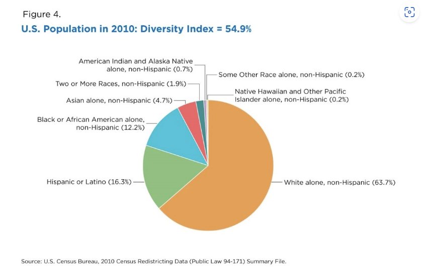

The analysis revealed a significant disparity between these two communities. average, the LatinX community experienced a higher **incarceration rate of 972.74 people jailed per 100,000**, while the White community’s **average was lower at 498.13 people jailed per 100,000**.

Over time, the incarceration rates for both communities displayed distinct trends. The average number of people jailed per 100,000 **decreased by 382.57** for the LatinX community. In contrast, the average incarceration rate for the White community **increased by 117.42**, reflecting a rise in comparison to the past.

These findings highlight the disparities in the US criminal justice system, emphasizing the need for further examination and efforts to address the inequities faced by the LatinX community in particular.

### The Dataset

Who collected the data?

- The data was collected/gathered by the Vera Institute of Justice, a national research and policy organization based in the United States that works on transforming the criminal legal and immigration systems until they’re fair for all.

How was the data collected or generated?

- The data was collected by gathering data from a multitude of other data sets. The Vera Institute uses data from the Bureau of Justice Statistics (BJS), the Census of Jails (COJ), the Annual Survey of Jails (ASJ), the Deaths in Custody Reporting Program (DCRP) and the National Corrections Reporting Program (NCRP) to create their Incarceration Trends data set.

Why was the data collected?

- The data was collected because it was the first national data set that can examined both jail and prison incarceration at the county level. Having a data set at this level of granularity is important because incarceration is usually decided by county officials, judges, wardens, and prosecutors. We can therefore use this data to see how decisions are made in communities across the U.S.

How many observations (rows) are in your data?

- There are 91031 observations (rows) in the data set.

How many features (columns) are in the data?

- There are 23 features (columns) in the data set.

What, if any, ethical questions or questions of power do you need to consider when working with this data?

- As mentioned in *Data Feminism* by Catherine D’Ignazio and Lauren F. Klein, it is important reflect on the data we are working with. In terms of questions of power and ethical questions, we must first understand that we are strangers to the data set and it extremely difficult to know the origin, context, and lived experiences of each individual represented by the data. We must also understand that most of the data gathered come from national organizations with positions of power. This means that it is likely that some perspectives are not included within the data set.

What are possible limitations or problems with this data? (at least 200 words)

- While evaluating the fairness of the U.S. criminal justice system, it is important to recognize that this data set only uses race and gender as measurements. This selective approach can create a framing cognitive bias and is not a holistic representation of the complex U.S. criminal justice system. The assignment further restricts the dimensions of evaluation by focusing on only comparing racial incarceration rates. While this information provides valuable insights, it fails to consider other important aspects of the criminal justice system such as recidivism rates and experiences while incarcerated. Limiting the analysis to racial incarceration also overlooks other crucial factors, such as socioeconomic status, education, systemic policies, and culture/family which can also influence arrests and sentencing. The dataset also doesn’t represent all racial groups as they exclude Asians, Native Hawaiians, and other Pacific Islanders. This means that the results from our data set cannot be generalized to “all racial groups.” Furthermore, it fails to mention how people who belong to multiple races are represented. The lack of this information obscures the experiences of multiracial individuals within the criminal justice system. Finally, multiple N/A values which represent missing information within the dataset introduces uncertainty into the calculated values, potentially leading to skewed or incomplete assessments of counties and states. (209 words)

### Trends Over Time Chart

Include a chart. Make sure to describe why you included the chart, and what patterns emerged

The first chart that you will create and include will show the trend over time of your variable/topic. Think carefully about what you want to communicate to your user (you may have to find relevant trends in the dataset first!). Here are some requirements to help guide your design:

- Show more than one, but fewer than ~10 trends
  - This may mean showing the same measure for different locations or different racial groups. Think carefully about a meaningful comparison of locations (e.g., the top 10 counties in a state, top 10 states, etc.)
- You must have clear x and y axis labels
- The chart needs a clear title
- You need a legend for your different line colors and a clear legend title

When we say “clear” or “human readable” titles and labels, that means that you should not just display the variable name.

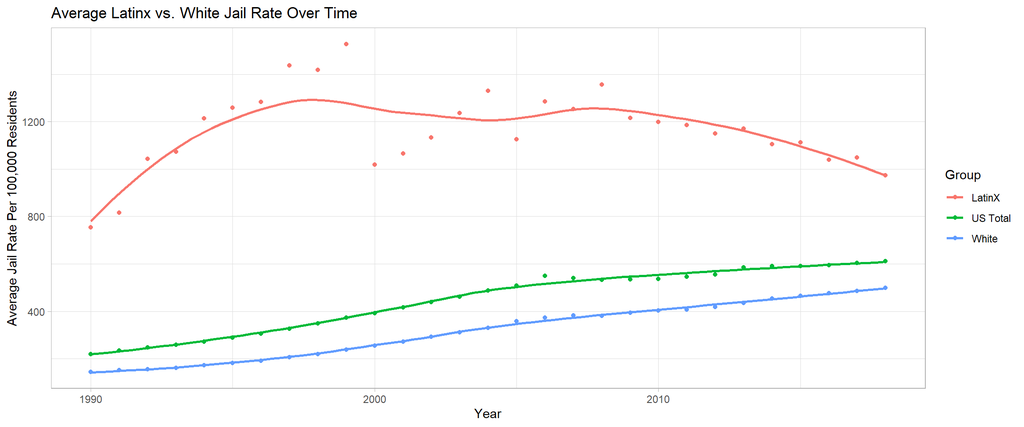

- This scatter plot is included to help visualize the trends of incarceration rates between the LatinX community and the rest of the United States. It highlights a decline in the LatinX jail rate per 100,000 residents, contrasted with a steady increase in incarceration rates for the rest of the United States. However, it’s essential to also notice that the LatinX jail rate remains significantly higher than both the US and White averages. By presenting these trends visually, we can gain a better perspective on the disparities and changes in incarceration rates among different racial groups in the country.

### Variable Comparison Chart

Include a chart. Make sure to describe why you included the chart, and what patterns emerged

The second chart that you will create and include will show how two different (continuous) variables are related to one another. Again, think carefully about what such a comparison means and what you want to communicate to your user (you may have to find relevant trends in the dataset first!). Here are some requirements to help guide your design:

- You must have clear x and y axis labels
- The chart needs a clear title
- If you choose to add a color encoding (not required), you need a legend for your different color and a clear legend title

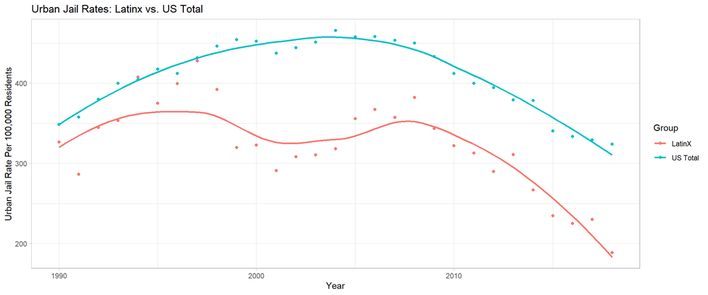

### Map

Include a chart. Make sure to describe why you included the chart, and what patterns emerged

The last chart that you will create and include will show how a variable is distributed geographically. Again, think carefully about what such a comparison means and what you want to communicate to your user (you may have to find relevant trends in the dataset first!). Here are some requirements to help guide your design:

- Your map needs a title
- Your color scale needs a legend with a clear label
- Use a map based coordinate system to set the aspect ratio of your map

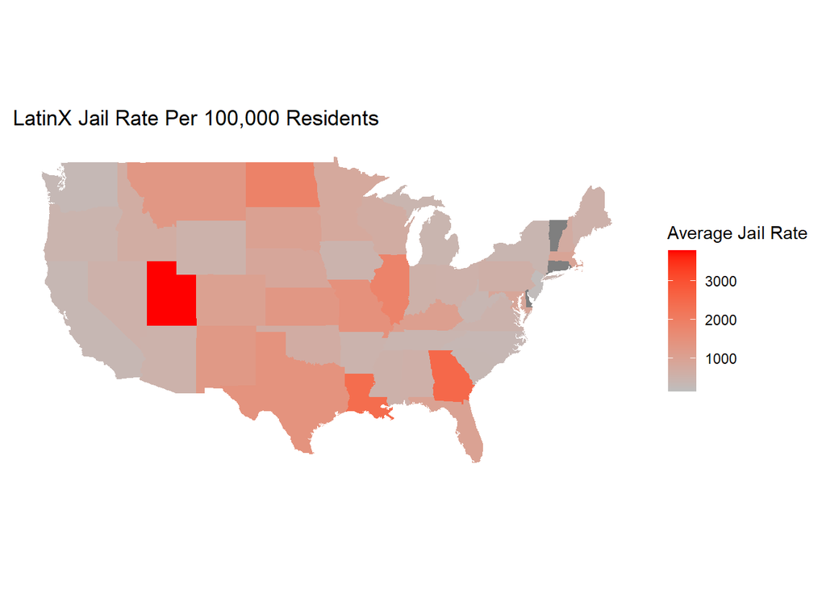